# tp1

diego orainde

# Datos de Empleo y Género

## Introducción

El siguiente informe, analiza datos del Banco Mundial sobre (des)empleo y género para algunos países de Latinoamérica y el Caribe, España y, en forma agregada, Latino America y Caribe, y el Mundo. El objetivo es el de visualizar y entender la situación laboral por sector y por género; realizar un informe sobre la evolución de los mismos; y evaluar el impacto de la legislación sobre acoso laboral, sobre los distinto niveles de empleo.

### Descripción de los datos

En principio, tenemos una tabla “ancha”, que en las columnas tiene: como variables, distintos niveles de empleo y desempeo, separados por género y por sector; 1 columna con el nombre del país o región; 1 columna con el código ISO de país o región, y el resto son columnas con los años en los que se encuantran los datos sobre las variables.

#### empleadoras_mujeres

Dentro de la fuerza laboral femenina, porcentaje de mujeres que tienen el rol de empleadoras. Se considera como “empleador” a personas cuya remuneración depende directamente de las ganancias derivadas de los bienes y servicios que produce y que tiene una o más personas empleadas.

#### empleadores_hombres

Dentro de la fuerza laboral femenina, porcentaje de hombres que tienen el rol de empleadores. Se considera como “empleador” a personas cuya remuneración depende directamente de las ganancias derivadas de los bienes y servicios que produce y que tiene una o más personas empleadas.

#### empleo_agricultura_mujeres

Dentro de la fuerza laboral femenina, porcentaje que trabaja en agricultura

#### empleo_agricultura_hombres

Dentro de la fuerza laboral masculina, porcentaje que trabaja en agricultura

#### empleo_industria_mujeres

Dentro de la fuerza laboral femenina, porcentaje que trabaja en industria

#### empleo_industria_hombres

Dentro de la fuerza laboral masculina, porcentaje que trabaja en industria

#### empleo_servicios_mujeres

Dentro de la fuerza laboral femenina, porcentaje que trabaja en servicios

#### empleo_servicios_hombres

Dentro de la fuerza laboral masculina, porcentaje que trabaja en servicios

#### empleo_informal_mujeres

Porcentaje de mujeres en empleos informales (no vinculados a la agricultura)

#### empleo_informal_hombres

Porcentaje de hombres en empleos informales (no vinculados a la agricultura)

#### legislacion_acoso_sexual

Existencia de legislación laboral contra acoso sexual laboral (`1` = `sí`, `0` = `no`)

#### autoempleo_mujeres

Mujeres trabajadoras por cuenta propia. Porcentaje dentro del total de la fuerza laboral femenina.

#### autoempleo_hombres

Hombres trabajadores por cuenta propia. Porcentaje dentro del total de la fuerza laboral masculina.

#### empleo_parcial_mujeres

Mujeres con trabajo a tiempo parcial. Porcentaje respecto del total de personas con trabajo a tiempo parcial.

#### desempleo_educacion_mujeres

Mujeres desempleadas con estudios terciarios. Porcentaje respecto del total de la fuerza laboral femenina con estudios terciarios.

#### desempleo_educacion_hombres

Hombres desempleados con estudios terciarios. Porcentaje respecto del total de la fuerza laboral masculina con estudios terciarios.

#### desempleo_mujeres

Mujeres desempleadas. Porcentaje respecto del total de la fuerza laboral femenina.

#### desempleo_hombres

Hombres desempleados. Porcentaje respecto del total de la fuerza laboral masculina.

#### trabajo_domestico_no_remunerado_mujeres

Porcentaje del día utilizado por mujeres en trabajo no remunerado doméstico y de cuidado.

#### trabajo_domestico_no_remunerado_hombres

Porcentaje del día utilizado por hombres en trabajo no remunerado doméstico y de cuidado.

## Exploración de los datos

```r
# Código para cargar o leer los datos

empleo_genero <- read_csv("datos/empleo_genero.csv")
empleo_genero
```

```
## # A tibble: 460 × 52
##    variable    pais_region codigo_pais_region `1970` `1971` `1972` `1973` `1974`
##    <chr>       <chr>       <chr>               <dbl>  <dbl>  <dbl>  <dbl>  <dbl>
##  1 empleadora… Argentina   ARG                    NA     NA     NA     NA     NA
##  2 empleadora… Bolivia     BOL                    NA     NA     NA     NA     NA
##  3 empleadora… Brasil      BRA                    NA     NA     NA     NA     NA
##  4 empleadora… Chile       CHL                    NA     NA     NA     NA     NA
##  5 empleadora… Colombia    COL                    NA     NA     NA     NA     NA
##  6 empleadora… Costa Rica  CRI                    NA     NA     NA     NA     NA
##  7 empleadora… Cuba        CUB                    NA     NA     NA     NA     NA
##  8 empleadora… Ecuador     ECU                    NA     NA     NA     NA     NA
##  9 empleadora… El Salvador SLV                    NA     NA     NA     NA     NA
## 10 empleadora… Guatemala   GTM                    NA     NA     NA     NA     NA
## # ℹ 450 more rows
## # ℹ 44 more variables: `1975` <dbl>, `1976` <dbl>, `1977` <dbl>, `1978` <dbl>,
## #   `1979` <dbl>, `1980` <dbl>, `1981` <dbl>, `1982` <dbl>, `1983` <dbl>,
## #   `1984` <dbl>, `1985` <dbl>, `1986` <dbl>, `1987` <dbl>, `1988` <dbl>,
## #   `1989` <dbl>, `1990` <dbl>, `1991` <dbl>, `1992` <dbl>, `1993` <dbl>,
## #   `1994` <dbl>, `1995` <dbl>, `1996` <dbl>, `1997` <dbl>, `1998` <dbl>,
## #   `1999` <dbl>, `2000` <dbl>, `2001` <dbl>, `2002` <dbl>, `2003` <dbl>, …
```

## **Descripción de los datos**

La tabla tiene una columna para cada año, y en la columna “variable”, tiene una fila por cada tipo de empleo y de situación frente al empleo, por cada país o región estudiado.

```r
empleo_genero |>
  group_by(pais_region)
```

```
## # A tibble: 460 × 52
## # Groups:   pais_region [23]
##    variable    pais_region codigo_pais_region `1970` `1971` `1972` `1973` `1974`
##    <chr>       <chr>       <chr>               <dbl>  <dbl>  <dbl>  <dbl>  <dbl>
##  1 empleadora… Argentina   ARG                    NA     NA     NA     NA     NA
##  2 empleadora… Bolivia     BOL                    NA     NA     NA     NA     NA
##  3 empleadora… Brasil      BRA                    NA     NA     NA     NA     NA
##  4 empleadora… Chile       CHL                    NA     NA     NA     NA     NA
##  5 empleadora… Colombia    COL                    NA     NA     NA     NA     NA
##  6 empleadora… Costa Rica  CRI                    NA     NA     NA     NA     NA
##  7 empleadora… Cuba        CUB                    NA     NA     NA     NA     NA
##  8 empleadora… Ecuador     ECU                    NA     NA     NA     NA     NA
##  9 empleadora… El Salvador SLV                    NA     NA     NA     NA     NA
## 10 empleadora… Guatemala   GTM                    NA     NA     NA     NA     NA
## # ℹ 450 more rows
## # ℹ 44 more variables: `1975` <dbl>, `1976` <dbl>, `1977` <dbl>, `1978` <dbl>,
## #   `1979` <dbl>, `1980` <dbl>, `1981` <dbl>, `1982` <dbl>, `1983` <dbl>,
## #   `1984` <dbl>, `1985` <dbl>, `1986` <dbl>, `1987` <dbl>, `1988` <dbl>,
## #   `1989` <dbl>, `1990` <dbl>, `1991` <dbl>, `1992` <dbl>, `1993` <dbl>,
## #   `1994` <dbl>, `1995` <dbl>, `1996` <dbl>, `1997` <dbl>, `1998` <dbl>,
## #   `1999` <dbl>, `2000` <dbl>, `2001` <dbl>, `2002` <dbl>, `2003` <dbl>, …
```

A partir de esto, podemos observar que la tabla tiene datos de 23 países/regiones.

```r
empleo_genero |>
  group_by(variable)
```

```
## # A tibble: 460 × 52
## # Groups:   variable [20]
##    variable    pais_region codigo_pais_region `1970` `1971` `1972` `1973` `1974`
##    <chr>       <chr>       <chr>               <dbl>  <dbl>  <dbl>  <dbl>  <dbl>
##  1 empleadora… Argentina   ARG                    NA     NA     NA     NA     NA
##  2 empleadora… Bolivia     BOL                    NA     NA     NA     NA     NA
##  3 empleadora… Brasil      BRA                    NA     NA     NA     NA     NA
##  4 empleadora… Chile       CHL                    NA     NA     NA     NA     NA
##  5 empleadora… Colombia    COL                    NA     NA     NA     NA     NA
##  6 empleadora… Costa Rica  CRI                    NA     NA     NA     NA     NA
##  7 empleadora… Cuba        CUB                    NA     NA     NA     NA     NA
##  8 empleadora… Ecuador     ECU                    NA     NA     NA     NA     NA
##  9 empleadora… El Salvador SLV                    NA     NA     NA     NA     NA
## 10 empleadora… Guatemala   GTM                    NA     NA     NA     NA     NA
## # ℹ 450 more rows
## # ℹ 44 more variables: `1975` <dbl>, `1976` <dbl>, `1977` <dbl>, `1978` <dbl>,
## #   `1979` <dbl>, `1980` <dbl>, `1981` <dbl>, `1982` <dbl>, `1983` <dbl>,
## #   `1984` <dbl>, `1985` <dbl>, `1986` <dbl>, `1987` <dbl>, `1988` <dbl>,
## #   `1989` <dbl>, `1990` <dbl>, `1991` <dbl>, `1992` <dbl>, `1993` <dbl>,
## #   `1994` <dbl>, `1995` <dbl>, `1996` <dbl>, `1997` <dbl>, `1998` <dbl>,
## #   `1999` <dbl>, `2000` <dbl>, `2001` <dbl>, `2002` <dbl>, `2003` <dbl>, …
```

Por tanto, la tabla tiene datos de una serie temporal, sobre 20 variables relacionadas con distintos tipo de empleo, para 23 países o regiones. Realizar un análisis sobre tantas variables y países distintos, resultaría en un estudio demasiado abarcativo y disperso. Por esto, es preferible enfocarse en algunos aspectos y países de interés, pudiéndose realizar un estudio comparado de la evolución de algunas variables relevantes.

## **Hipótesis**

En una primera inspección de los datos, se puede ver que los datos de empleo, estan separados por género, de modo que no pueden compararse como parte de un conjunto poblacional. Esto es que, por ejemplo, el desempleo_ mujeres tiene la tasa de mujeres desempleadas entre las mujeres, o que la suma del empleo industrial, agrícola y de servicios, sume el 100 % del empleo de cada género, o sea que sumando los datos de los dos géneros se obtiene el 200%…

Igualmente, con estos datos me interesaría realizar gráficas para ver cómo ha cambiado el porcentaje de trabajadores de cada sector de la economía (en estos 3 grandes grupos: industria, agricultura y servicios), y ver la tasa de desempleo como principio para un análisis más grande que involucre acontecimientos económicos mundiales y locales, y su impacto en los niveles de empleo.

## Metodología

Para lo que sigue, hay a acomodar la tabla para poder trabajar los datos

1. Como la tabla tiene los años como columnas y los años son datos, hay que transformar esta tabla “ancha” en una “larga”.
2. A su vez, las variables se encuentra agrupadas en una columna, por lo que hay que abrirla en varias columnas para que puedan intersectarse los datos entre años y países, y las variables.
3. Hay que seleccionar las variables a investigar, y el país/países que presenten interés, para no dispersar el estudio
4. Observar los resultados, y aproximar algunas hipótesis con algunos de los resultados
5. Intentar algunas conclusiones

### **1- Tabla larga**

Debido a que los datos se corresponden con los de una serie de tiempo, para poder estudiar su “evolución” en el tiempo, conviene disponerlos en una columna, y luego, disponer variables en columnas.

```r
empleo_genero_largo <- empleo_genero |>
  pivot_longer(cols = c("1970":"2018"),
               names_to = "anio" , values_to = "valor") |>
  arrange(anio)
```

```r
empleo_genero_largo
```

```
## # A tibble: 22,540 × 5
##    variable            pais_region codigo_pais_region anio  valor
##    <chr>               <chr>       <chr>              <chr> <dbl>
##  1 empleadoras_mujeres Argentina   ARG                1970     NA
##  2 empleadoras_mujeres Bolivia     BOL                1970     NA
##  3 empleadoras_mujeres Brasil      BRA                1970     NA
##  4 empleadoras_mujeres Chile       CHL                1970     NA
##  5 empleadoras_mujeres Colombia    COL                1970     NA
##  6 empleadoras_mujeres Costa Rica  CRI                1970     NA
##  7 empleadoras_mujeres Cuba        CUB                1970     NA
##  8 empleadoras_mujeres Ecuador     ECU                1970     NA
##  9 empleadoras_mujeres El Salvador SLV                1970     NA
## 10 empleadoras_mujeres Guatemala   GTM                1970     NA
## # ℹ 22,530 more rows
```

En esa tabla, las variables se repiten para cada país y cada año, determinando una tabala con 22540 filas. Puede verse que en la columna `valor´, faltan datos para varios años y variables.

```r
empleo_genero_largo |>
  filter(valor > 0) |>
  group_by(anio) |>
  summarise(n=n()) |>
  arrange(anio)
```

```
## # A tibble: 49 × 2
##    anio      n
##    <chr> <int>
##  1 1970      2
##  2 1971      2
##  3 1972      2
##  4 1973      4
##  5 1974      8
##  6 1975      4
##  7 1976      8
##  8 1977     10
##  9 1978      6
## 10 1979     10
## # ℹ 39 more rows
```

De este modo, puede observarse que para los primeros 20 años de la muestra, existen pocas observaciones. Esto podría distorsionar las conclusiones que puedan llevarse adelante o mediante gráficos o por análisis de los datos. Con esta disposición de los datos, también puede obtenerse que el estudio abarca 49 años.

La falta de datos en distintos años, para distintas variables y distintos países, dificulta obtener datos como el promedio.

### Una primera aproximación a las variables, por género.

#### Mujeres

```r
tipo_empleo_m <- c("empleo_industria_mujeres","empleo_servicios_mujeres", "empleo_agricultura_mujeres", "desempleo_mujeres")


 for (i in tipo_empleo_m) {
   empleo_genero_largo |>
   filter(variable == i,
          valor < 99.99,
          pais_region == c("Brasil","España", "Argentina")) |>
   ggplot(aes(anio, valor)) +
   geom_line(aes(group = pais_region, color = as.factor(pais_region))) +
     labs(title = paste0("Tipo de empleo ", i))
 ggsave(paste0("tipo_empleo_", i, ".png"))


}
```

#### Hombres

```r
tipo_empleo_h <- c("empleo_industria_hombres","empleo_servicios_hombres", "empleo_agricultura_hombres", "desempleo_hombres")


 for (i in tipo_empleo_h) {
   empleo_genero_largo |>
   filter(variable == i,
          valor < 99.99,
          pais_region == c("Brasil","España", "Argentina")) |>
   ggplot(aes(anio, valor)) +
   geom_line(aes(group = pais_region, color = as.factor(pais_region))) +
     labs(title = paste0("Tipo de empleo ", i))
 ggsave(paste0("tipo_empleo_", i, ".png"))


}
```

### **2- Un valor para cada variable**

Como las variables se encuentran en una sola columna, hay que desagregarla para poder relacionar la variable con determinado año, para cada país

```r
empleo_genero_ancho <- empleo_genero_largo |>
    pivot_wider(names_from = variable, values_from = valor)
empleo_genero_ancho
```

```
## # A tibble: 1,127 × 23
##    pais_region codigo_pais_region anio  empleadoras_mujeres empleadores_hombres
##    <chr>       <chr>              <chr>               <dbl>               <dbl>
##  1 Argentina   ARG                1970                   NA                  NA
##  2 Bolivia     BOL                1970                   NA                  NA
##  3 Brasil      BRA                1970                   NA                  NA
##  4 Chile       CHL                1970                   NA                  NA
##  5 Colombia    COL                1970                   NA                  NA
##  6 Costa Rica  CRI                1970                   NA                  NA
##  7 Cuba        CUB                1970                   NA                  NA
##  8 Ecuador     ECU                1970                   NA                  NA
##  9 El Salvador SLV                1970                   NA                  NA
## 10 Guatemala   GTM                1970                   NA                  NA
## # ℹ 1,117 more rows
## # ℹ 18 more variables: empleo_agricultura_mujeres <dbl>,
## #   empleo_agricultura_hombres <dbl>, empleo_industria_mujeres <dbl>,
## #   empleo_industria_hombres <dbl>, empleo_servicios_mujeres <dbl>,
## #   empleo_servicios_hombres <dbl>, empleo_informal_mujeres <dbl>,
## #   empleo_informal_hombres <dbl>, legislacion_acoso_sexual <dbl>,
## #   autoempleo_mujeres <dbl>, autoempleo_hombres <dbl>, …
```

Ahora volvemos a tener muchas columnas (23), pero se pueden filtrar para estudiar de a una. Por ejemplo:

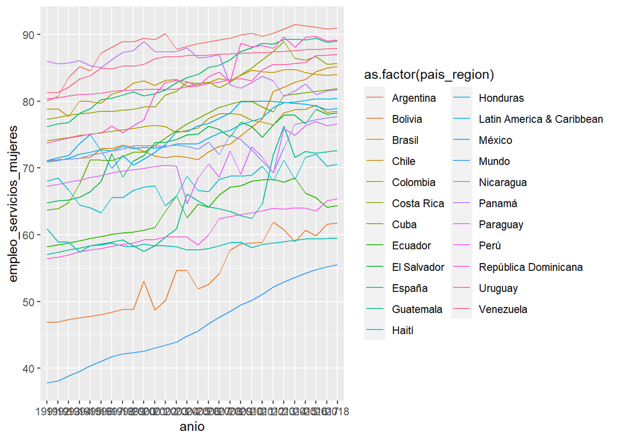

```r
empleo_genero_ancho |>
  filter(empleo_servicios_mujeres < 99.99) |>
  ggplot(aes(anio, empleo_servicios_mujeres)) +
  geom_line(aes(group = pais_region, color = as.factor(pais_region)))
```

En el fitro se colocó que la variables sea < a 99.99 para impedir que se tomen datos erróneos que superen ese número ya que son tasas porcentuales y no deben superar el 100 %. A su vez, evita la corrupción de la ausencia de datos.

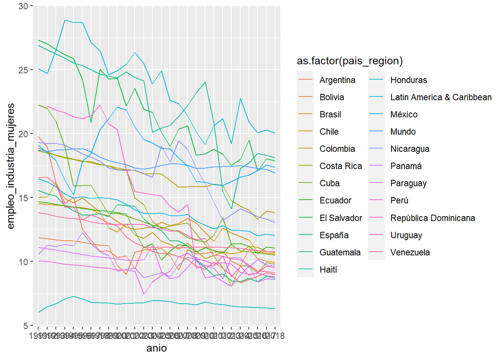

```r
empleo_genero_ancho |>
  filter(empleo_industria_mujeres < 99.99) |>
  ggplot(aes(anio, empleo_industria_mujeres)) +
  geom_line(aes(group = pais_region, color = as.factor(pais_region)))
```

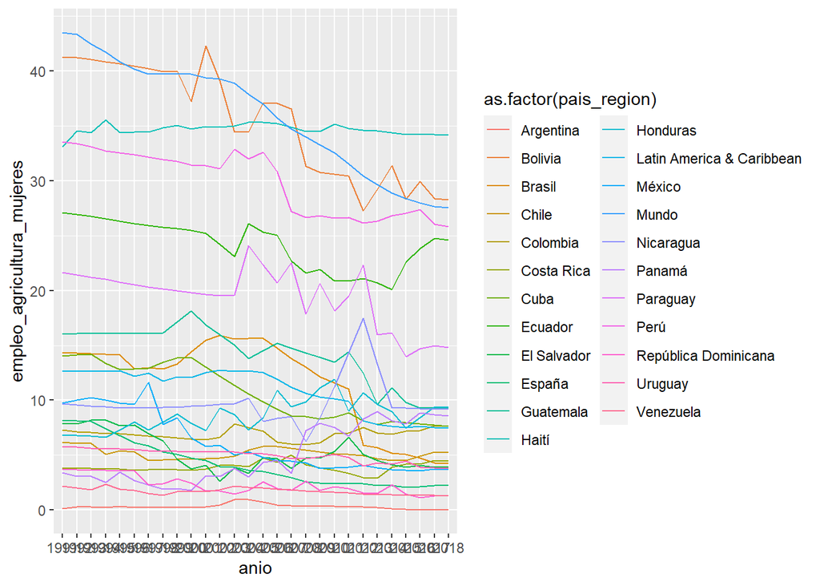

```r
empleo_genero_ancho |>
  filter(empleo_agricultura_mujeres < 99.99) |>
  ggplot(aes(anio, empleo_agricultura_mujeres)) +
  geom_line(aes(group = pais_region, color = as.factor(pais_region)))
```

```r
desempleo_promedio <- empleo_genero_ancho |>
  group_by(pais_region) |>
  summarise(mean(desempleo_mujeres, na.rm = TRUE),
            mean(desempleo_hombres, na.rm = TRUE))
desempleo_promedio
```

```
## # A tibble: 23 × 3
##    pais_region `mean(desempleo_mujeres, na.rm = TRUE)` mean(desempleo_hombres,…¹
##    <chr>                                         <dbl>                     <dbl>
##  1 Argentina                                     12.2                       9.92
##  2 Bolivia                                        5.54                      7.03
##  3 Brasil                                         8.23                      5.60
##  4 Chile                                         10.7                       8.88
##  5 Colombia                                      15.0                       9.20
##  6 Costa Rica                                     7.54                      4.85
##  7 Cuba                                           5.19                      2.92
##  8 Ecuador                                        7.85                      4.60
##  9 El Salvador                                    6.16                      7.87
## 10 España                                        17.4                      16.4
## # ℹ 13 more rows
## # ℹ abbreviated name: ¹`mean(desempleo_hombres, na.rm = TRUE)`
```

Puede observarse que mayormente la tasa de desempleo femenina es mayor que la masculina en promedio.

```r
desempleo_max_min <- empleo_genero_ancho |>
  group_by(pais_region) |>
  summarise(min(desempleo_mujeres, na.rm = TRUE),
            max(desempleo_mujeres, na.rm = TRUE),
            min(desempleo_hombres, na.rm = TRUE),
            max(desempleo_hombres, na.rm = TRUE))
desempleo_max_min
```

```
## # A tibble: 23 × 5
##    pais_region `min(desempleo_mujeres, na.rm = TRUE)` max(desempleo_mujeres, n…¹
##    <chr>                                        <dbl>                      <dbl>
##  1 Argentina                                     4.19                       22.3
##  2 Bolivia                                       2.03                       12.6
##  3 Brasil                                        1.90                       14.7
##  4 Chile                                         5.10                       18.2
##  5 Colombia                                     10.8                        24.5
##  6 Costa Rica                                    4.97                       12.8
##  7 Cuba                                          1.87                       13.0
##  8 Ecuador                                       3.65                       19.2
##  9 El Salvador                                   3.14                       24.4
## 10 España                                        2                          26.7
## # ℹ 13 more rows
## # ℹ abbreviated name: ¹`max(desempleo_mujeres, na.rm = TRUE)`
## # ℹ 2 more variables: `min(desempleo_hombres, na.rm = TRUE)` <dbl>,
## #   `max(desempleo_hombres, na.rm = TRUE)` <dbl>
```

Lo mismo observamos tanto para los mínimos como los máximos, que en ambos casos son más altos para las mujeres que para los hombres. Una primera conclusión puede ser que **las mujeres son más vulnerables en su situación frente al empleo que los hombres**,

### **3- Tomamos para el análisis a Brasil, Argentina y España, y el Mundo como un todo.**

```r
pais <- c("Brasil","España", "Argentina", "Mundo")


for (i in pais) {
  empleo_genero_ancho |>
  filter(empleo_industria_mujeres < 99.99,
         pais_region == i) |>
  ggplot(aes(anio, empleo_industria_mujeres)) +
  geom_line(aes(group = pais_region, color = as.factor(pais_region))) +
    labs(title = paste0("Empleo industria mujeres ", i))
ggsave(paste0("empleo_industria_mujeres_", i, ".png"))


}
```

## **4- Un poco de análisis comparativo**

A partir de los datos obtenidos, se desprende que el trabajo tanto en hombres como mujeres, ha ido mutando hacia el sector servicios. Pero, ¿qué sucede en particular con Argentina?

Se sabe que Argentina es un país agroexportador; lo mismo ocurre con Brasil, aunque se reconocce que tuvo un desarrollo industrial mayor durante la dictadura militar. Sin embargo, no parece reflejarse en el tipo de empleo que ofrece a sus trabajadores.

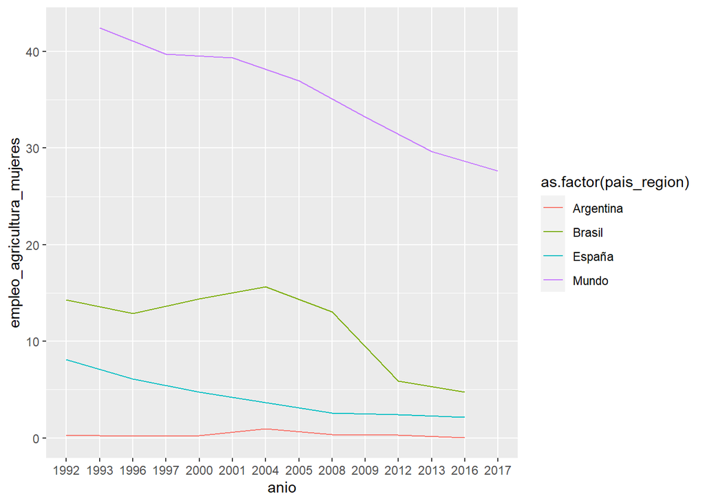

```r
empleo_genero_ancho |>
  filter(empleo_agricultura_mujeres < 99.99,
         pais_region == c("Brasil","España", "Argentina", "Mundo")) |>
  ggplot(aes(anio, empleo_agricultura_mujeres)) +
  geom_line(aes(group = pais_region, color = as.factor(pais_region)))
```

Puede verse, que que la agricultura disminuye su poder como generadora de empleos. Pero en Argentina, llama la atención por ser un país agroexportador. La oferta de empleos agropecuarios es muy baja y casi no parece ofrecer puestos laborales.

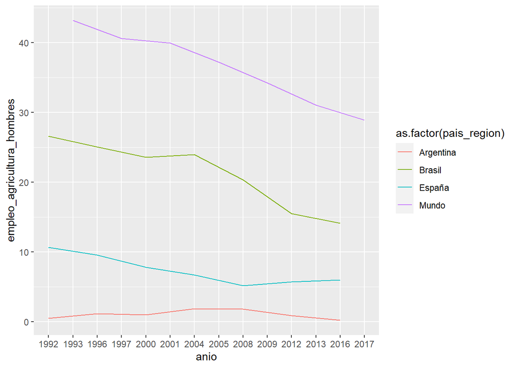

```r
empleo_genero_ancho |>
  filter(empleo_agricultura_hombres < 99.99,
    pais_region == c("Brasil","España", "Argentina", "Mundo")) |>
  ggplot(aes(anio, empleo_agricultura_hombres)) +
  geom_line(aes(group = pais_region, color = as.factor(pais_region)))
```

Lo mismo sucede en el empleo agrícola para hombres.

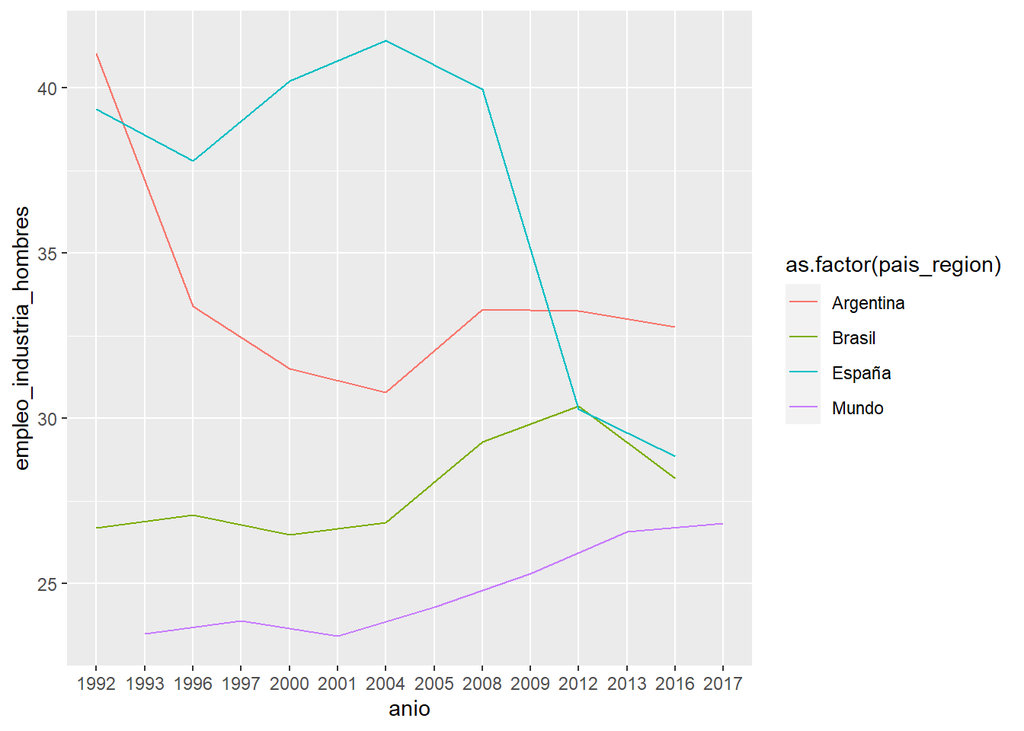

```r
empleo_genero_ancho |>
  filter(empleo_industria_hombres < 99.99,
         pais_region == c("Brasil","España", "Argentina", "Mundo")) |>
  ggplot(aes(anio, empleo_industria_hombres)) +
  geom_line(aes(group = pais_region, color = as.factor(pais_region)))
```

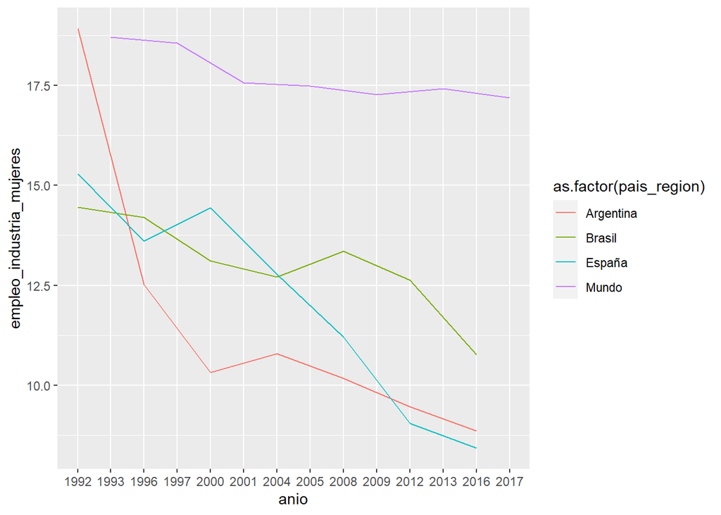

```r
empleo_genero_ancho |>
  filter(empleo_industria_mujeres < 99.99,
         pais_region == c("Brasil","España", "Argentina", "Mundo")) |>
  ggplot(aes(anio, empleo_industria_mujeres)) +
  geom_line(aes(group = pais_region, color = as.factor(pais_region)))
```

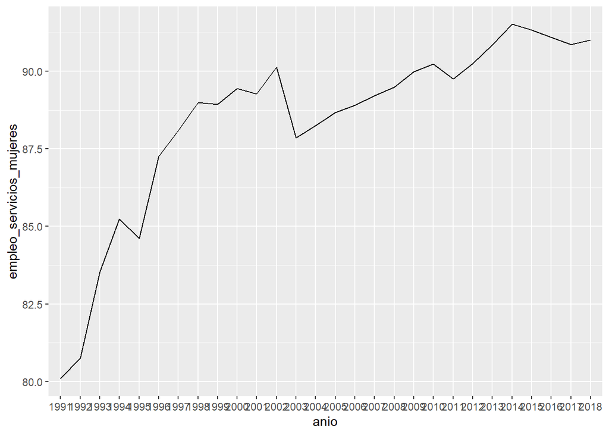

```r
empleo_genero_ancho |>
  filter(empleo_servicios_mujeres < 99.99,
         pais_region == "Argentina") |>
  ggplot(aes(anio, empleo_servicios_mujeres)) +
  geom_line(aes(group = "Argentina"))
```

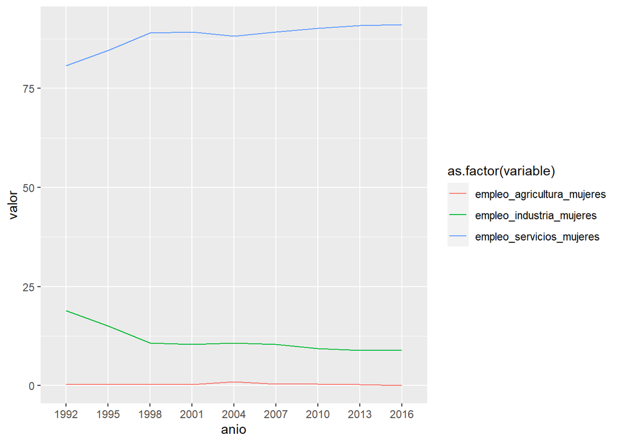

```r
  empleo_genero_largo |>
   filter(variable == c("empleo_industria_mujeres", "empleo_servicios_mujeres", "empleo_agricultura_mujeres"),
          valor < 99.99,
          pais_region == "Argentina") |>
   ggplot(aes(anio, valor)) +
   geom_line(aes(group = variable, color = as.factor(variable)))
```

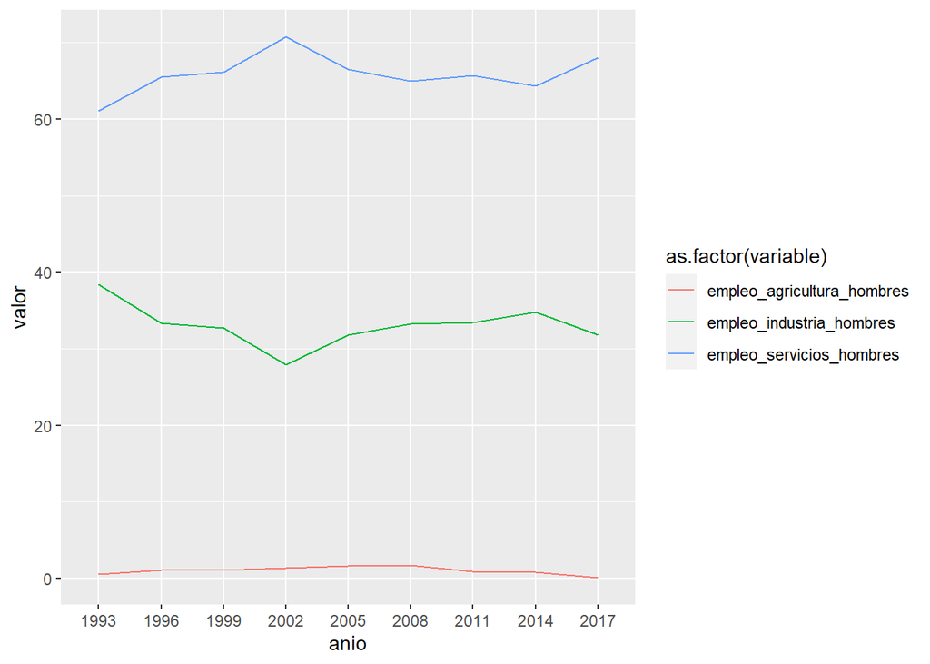

```r
  empleo_genero_largo |>
   filter(variable == c("empleo_industria_hombres", "empleo_servicios_hombres", "empleo_agricultura_hombres"),
          valor < 99.99,
          pais_region == "Argentina") |>
   ggplot(aes(anio, valor)) +
   geom_line(aes(group = variable, color = as.factor(variable)))
```

## **5- Conclusiones**

A partir de los datos provenientes de una serie temporal de la base de datos del Banco Mundial, analizamos la situación frente al empleo en distintos países, y su evolución con los años. Se puede observar una tendencia, aunque con la limitación de los conocimientos sobre las herramientas que ofrece RStudio, no he podido profundizar sobre el tema. Hubiera sido necesario realizar una regresión lineal e interpretar los resultados, pero supera mis conocimiento actuales. Al margen de esta situación, se han podido analizar algunos aspectos que ponen de manifiesto las diferencias en los tipos de empleo atravesado por el factor género. Los hombres, tiene una mayor proporción de empleos industriales que las mujeres; empleos que en principio ofrecen mejores salarios promedio. Por otro lado, la mayoría de las mujeres tiene empleos del sector servicios. Merecería un análisis desagregado para poder determinar en qué tipos de empleo del sector servicios tiene mayor presencia y evaluar distintos aspectos como podría ser la diferencia salarial.